# 01_class

```python
import matplotlib.pyplot as plt
import pandas as pd
import numpy as np
```

```python
# np.linsapce(시작, 끝, 데이터 개수)
x = np.linspace(0, 14, 100)
y1 = np.sin(x)
```

```python
x
```

```
array([ 0.        ,  0.14141414,  0.28282828,  0.42424242,  0.56565657,
        0.70707071,  0.84848485,  0.98989899,  1.13131313,  1.27272727,
        1.41414141,  1.55555556,  1.6969697 ,  1.83838384,  1.97979798,
        2.12121212,  2.26262626,  2.4040404 ,  2.54545455,  2.68686869,
        2.82828283,  2.96969697,  3.11111111,  3.25252525,  3.39393939,
        3.53535354,  3.67676768,  3.81818182,  3.95959596,  4.1010101 ,
        4.24242424,  4.38383838,  4.52525253,  4.66666667,  4.80808081,
        4.94949495,  5.09090909,  5.23232323,  5.37373737,  5.51515152,
        5.65656566,  5.7979798 ,  5.93939394,  6.08080808,  6.22222222,
        6.36363636,  6.50505051,  6.64646465,  6.78787879,  6.92929293,
        7.07070707,  7.21212121,  7.35353535,  7.49494949,  7.63636364,
        7.77777778,  7.91919192,  8.06060606,  8.2020202 ,  8.34343434,
        8.48484848,  8.62626263,  8.76767677,  8.90909091,  9.05050505,
        9.19191919,  9.33333333,  9.47474747,  9.61616162,  9.75757576,
        9.8989899 , 10.04040404, 10.18181818, 10.32323232, 10.46464646,
       10.60606061, 10.74747475, 10.88888889, 11.03030303, 11.17171717,
       11.31313131, 11.45454545, 11.5959596 , 11.73737374, 11.87878788,
       12.02020202, 12.16161616, 12.3030303 , 12.44444444, 12.58585859,
       12.72727273, 12.86868687, 13.01010101, 13.15151515, 13.29292929,
       13.43434343, 13.57575758, 13.71717172, 13.85858586, 14.        ])
```

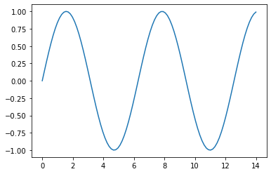

```python
plt.plot(x, y1)
```

##### 1-2 실습 - 3개 그래프 그리기

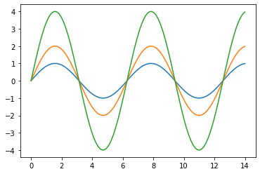

```python
x = np.linspace(0, 14, 100)
y1 = np.sin(x)
y2 = np.sin(x) * 2
y3 = np.sin(x) * 4
plt.plot(x, y1, x, y2, x, y3)
```

##### 1-2 (추가) cos, tan 그래프 그려보기

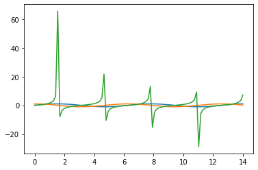

```python
x = np.linspace(0, 14, 100)
y1 = np.sin(x)
y2 = np.cos(x)
y3 = np.tan(x)
plt.plot(x, y1, x, y2, x, y3)
```

###### 1-2 (추가) 선그래프가 아닌 점 형태로 plot해보기

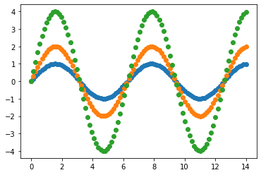

```python
# plt.plot(x축 값, y축 값, '그래프 형태')
plt.plot(x, y1, 'o')
plt.plot(x, y2, 'o')
plt.plot(x, y3, 'o')
```

#### 새로운 스타일 적용

```python
import seaborn as sns
```

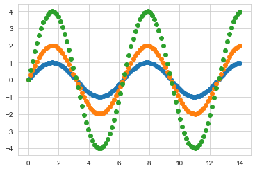

```python
sns.set_style('whitegrid')
plt.plot(x, y1, 'o')
plt.plot(x, y2, 'o')
plt.plot(x, y3, 'o')
```

### tip 데이터로 데이터 살펴보고 인사이트 얻기

```python
tips = sns.load_dataset('tips')
type(tips)
```

```
pandas.core.frame.DataFrame
```

```python
# 01 앞뒤의 5개의 행 보기 [].head(), [].tail()
# 02 데이터 통계량 보기 [].describe()
# 03 컬럼 확인 [].columns
# 04 전체 정보확인하기 [].info()
# 05 행과 열을 확인하기 [].shape
```

```python
tips.head()
```

|  | total_bill | tip | sex | smoker | day | time | size |
| --- | --- | --- | --- | --- | --- | --- | --- |
| 0 | 16.99 | 1.01 | Female | No | Sun | Dinner | 2 |
| 1 | 10.34 | 1.66 | Male | No | Sun | Dinner | 3 |
| 2 | 21.01 | 3.50 | Male | No | Sun | Dinner | 3 |
| 3 | 23.68 | 3.31 | Male | No | Sun | Dinner | 2 |
| 4 | 24.59 | 3.61 | Female | No | Sun | Dinner | 4 |

```python
tips.columns
```

```
Index(['total_bill', 'tip', 'sex', 'smoker', 'day', 'time', 'size'], dtype='object')
```

```python
tips.shape
```

```
(244, 7)
```

```python
tips.info()
```

```
<class 'pandas.core.frame.DataFrame'>
RangeIndex: 244 entries, 0 to 243
Data columns (total 7 columns):
 #   Column      Non-Null Count  Dtype
---  ------      --------------  -----
 0   total_bill  244 non-null    float64
 1   tip         244 non-null    float64
 2   sex         244 non-null    category
 3   smoker      244 non-null    category
 4   day         244 non-null    category
 5   time        244 non-null    category
 6   size        244 non-null    int64
dtypes: category(4), float64(2), int64(1)
memory usage: 7.4 KB
```

```python
tips.head(7)
```

|  | total_bill | tip | sex | smoker | day | time | size |
| --- | --- | --- | --- | --- | --- | --- | --- |
| 0 | 16.99 | 1.01 | Female | No | Sun | Dinner | 2 |
| 1 | 10.34 | 1.66 | Male | No | Sun | Dinner | 3 |
| 2 | 21.01 | 3.50 | Male | No | Sun | Dinner | 3 |
| 3 | 23.68 | 3.31 | Male | No | Sun | Dinner | 2 |
| 4 | 24.59 | 3.61 | Female | No | Sun | Dinner | 4 |
| 5 | 25.29 | 4.71 | Male | No | Sun | Dinner | 4 |
| 6 | 8.77 | 2.00 | Male | No | Sun | Dinner | 2 |

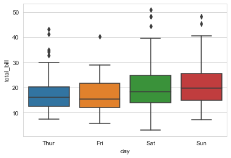

```python
### 요일별 식사금액은 얼마나 될까?
# 주의! x="범주형 데이터"(숫자형 데이터가 들어가면 안된다.)
sns.boxplot(x='day', y='total_bill', data=tips)
plt.show()
```

- 식사금액은 토요일과 일요일이 많구나
- 현재 데이터는 목, 금, 토, 일 의 데이터가 있구나.
- 토요일과 일요일을 비교하면 상대적으로 일요일에 식사 지출 금액이 많다.

##### 2-1 실습 - 요일별 팁 - 댓글 달기

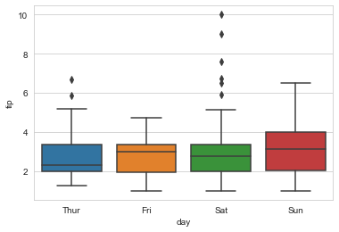

```python
sns.boxplot(x='day', y='tip', data=tips)
plt.show()
```

- 일요일에 팁이 가장 많다.
- 일요일에 팁 범위가 가장 크다.
- 토요일에 팁 이산값이 많다.
- 금요일에 중앙값이 높은 편이다.

##### 2-2 실습 - 요일별 사이즈(식사인원) - 댓글 달기

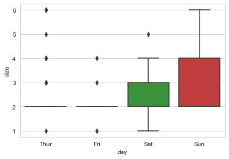

```python
sns.boxplot(x='day', y='size', data=tips)
plt.show()
```

- 토, 일 에 식사 인원이 많다 # 데이터간의 상관관계를 발견할 수 있다.
  - 그래서 식사 금액과 팁 금액이 많다.
    - 주말에 가족 식사가 많다. 그에 따른 판매 전략을 세우는 데 도움을 줄 수 있다.
- 목, 금 에 식사 인원은 2명 대다수이다.

### 누가 팁을 많이 주는 걸까?

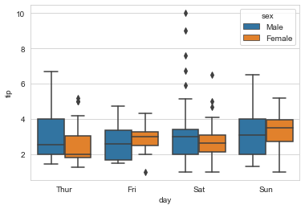

```python
sns.boxplot(x='day', y='tip', hue='sex', data=tips)
```

- 남성들이 주는 팁의 범위가 크다.
- 토요일은 이상치가 많다.
- 의문 - 토요일 남성의 팁이 많은 이유. (데이터 결과에 의문을 가지고 원인, 상관관계 등을 파악하는 것이 중요.)

```python
tips.columns
```

```
Index(['total_bill', 'tip', 'sex', 'smoker', 'day', 'time', 'size'], dtype='object')
```

##### 2-3 담배 피우는 사람과 안피는 사람 팁의 관계 - 댓글

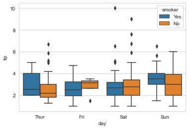

```python
sns.boxplot(x='day', y='tip', hue='smoker', data=tips)
```

- 목, 금에 담배 피는 사람의 팁의 범위가 크다.

##### 2-3 time과 팁의 관계 - 댓글

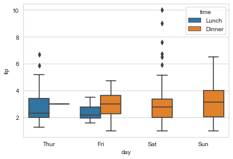

```python
sns.boxplot(x='day', y='tip', hue='time', data=tips)
```

- 목, 금은 점심 식사가 많다.
- 금은 점심과 저녁 식사가 둘다 많다.
- 토, 일은 저녁 식사만 있다.
  - 주말은 집에서 휴식을 취하는 사람이 많기에 저녁식사 비중이 높다 생각된다.

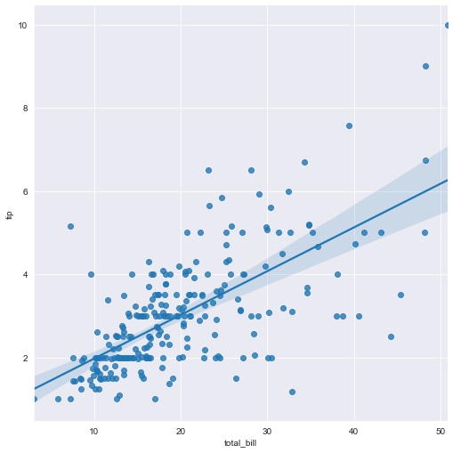

```python
sns.set_style('darkgrid')
sns.lmplot(x='total_bill', y='tip', data=tips, size=7)
plt.show()
```

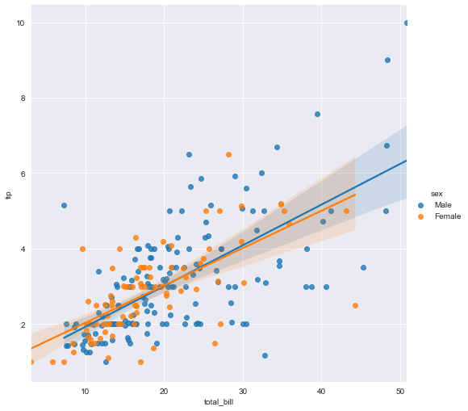

```python
sns.set_style('darkgrid')
sns.lmplot(x='total_bill', y='tip', hue='sex', data=tips, size=7)
plt.show()
```

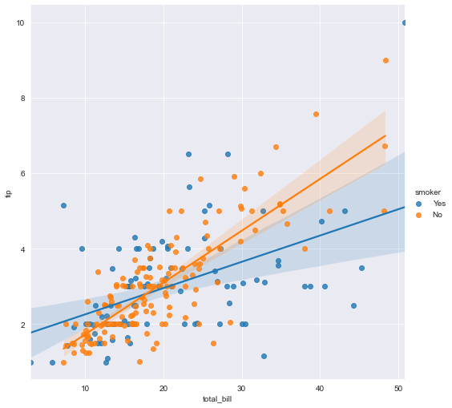

```python
sns.set_style('darkgrid')
sns.lmplot(x='total_bill', y='tip', hue='smoker', data=tips, size=7)
plt.show()
```

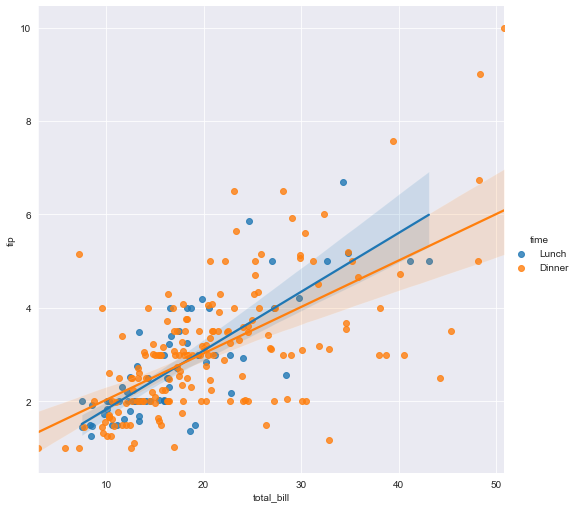

```python
sns.set_style('darkgrid')
sns.lmplot(x='total_bill', y='tip', hue='time', data=tips, size=7)
plt.show()
```

### 항공 데이터 이용

```python
fg = sns.load_dataset('flights')
fg
```

|  | year | month | passengers |
| --- | --- | --- | --- |
| 0 | 1949 | Jan | 112 |
| 1 | 1949 | Feb | 118 |
| 2 | 1949 | Mar | 132 |
| 3 | 1949 | Apr | 129 |
| 4 | 1949 | May | 121 |
| ... | ... | ... | ... |
| 139 | 1960 | Aug | 606 |
| 140 | 1960 | Sep | 508 |
| 141 | 1960 | Oct | 461 |
| 142 | 1960 | Nov | 390 |
| 143 | 1960 | Dec | 432 |

144 rows × 3 columns

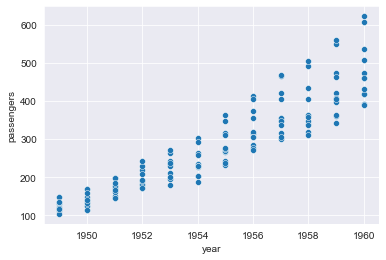

```python
sns.scatterplot(x='year', y='passengers', data=fg)
```

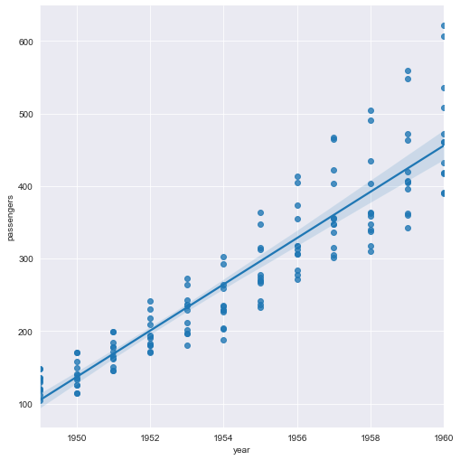

```python
sns.set_style('darkgrid')
sns.lmplot(x='year', y='passengers', data=fg, size=7)
plt.show()
```

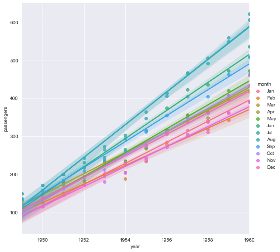

```python
sns.set_style('darkgrid')
sns.lmplot(x='year', y='passengers', hue='month', data=fg, size=7) # size 대신 height를 사용하도록 경고
plt.show()
```

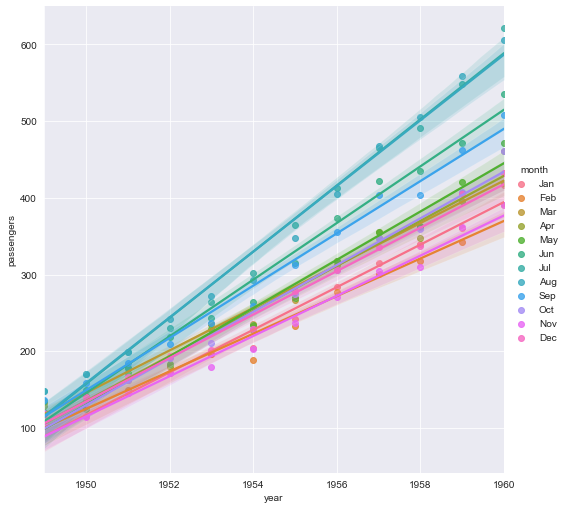

```python
sns.set_style('darkgrid')
sns.lmplot(x='year', y='passengers', hue='month', data=fg, height=7) # size대신 height를 사용
plt.show()
```

```python
fgpivot = fg.pivot('month', 'year', 'passengers')
fgpivot
```

| year month | 1949 | 1950 | 1951 | 1952 | 1953 | 1954 | 1955 | 1956 | 1957 | 1958 | 1959 | 1960 |
| --- | --- | --- | --- | --- | --- | --- | --- | --- | --- | --- | --- | --- |
| Jan | 112 | 115 | 145 | 171 | 196 | 204 | 242 | 284 | 315 | 340 | 360 | 417 |
| Feb | 118 | 126 | 150 | 180 | 196 | 188 | 233 | 277 | 301 | 318 | 342 | 391 |
| Mar | 132 | 141 | 178 | 193 | 236 | 235 | 267 | 317 | 356 | 362 | 406 | 419 |
| Apr | 129 | 135 | 163 | 181 | 235 | 227 | 269 | 313 | 348 | 348 | 396 | 461 |
| May | 121 | 125 | 172 | 183 | 229 | 234 | 270 | 318 | 355 | 363 | 420 | 472 |
| Jun | 135 | 149 | 178 | 218 | 243 | 264 | 315 | 374 | 422 | 435 | 472 | 535 |
| Jul | 148 | 170 | 199 | 230 | 264 | 302 | 364 | 413 | 465 | 491 | 548 | 622 |
| Aug | 148 | 170 | 199 | 242 | 272 | 293 | 347 | 405 | 467 | 505 | 559 | 606 |
| Sep | 136 | 158 | 184 | 209 | 237 | 259 | 312 | 355 | 404 | 404 | 463 | 508 |
| Oct | 119 | 133 | 162 | 191 | 211 | 229 | 274 | 306 | 347 | 359 | 407 | 461 |
| Nov | 104 | 114 | 146 | 172 | 180 | 203 | 237 | 271 | 305 | 310 | 362 | 390 |
| Dec | 118 | 140 | 166 | 194 | 201 | 229 | 278 | 306 | 336 | 337 | 405 | 432 |

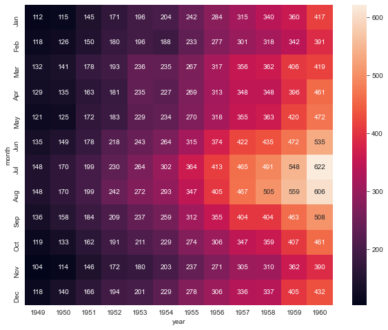

```python
plt.figure(figsize=(10,8))
sns.heatmap(fgpivot, annot=True, fmt='d')
plt.show()
# annot=True : 컴퓨터 숫자로 표현한다.
# fmt='d' : 컴퓨터 숫자를 알아보기 쉬운 숫자를 표현한다.
```

```python
sns.set(style='ticks')
iris = sns.load_dataset('iris')
iris
```

|  | sepal_length | sepal_width | petal_length | petal_width | species |
| --- | --- | --- | --- | --- | --- |
| 0 | 5.1 | 3.5 | 1.4 | 0.2 | setosa |
| 1 | 4.9 | 3.0 | 1.4 | 0.2 | setosa |
| 2 | 4.7 | 3.2 | 1.3 | 0.2 | setosa |
| 3 | 4.6 | 3.1 | 1.5 | 0.2 | setosa |
| 4 | 5.0 | 3.6 | 1.4 | 0.2 | setosa |
| ... | ... | ... | ... | ... | ... |
| 145 | 6.7 | 3.0 | 5.2 | 2.3 | virginica |
| 146 | 6.3 | 2.5 | 5.0 | 1.9 | virginica |
| 147 | 6.5 | 3.0 | 5.2 | 2.0 | virginica |
| 148 | 6.2 | 3.4 | 5.4 | 2.3 | virginica |
| 149 | 5.9 | 3.0 | 5.1 | 1.8 | virginica |

150 rows × 5 columns

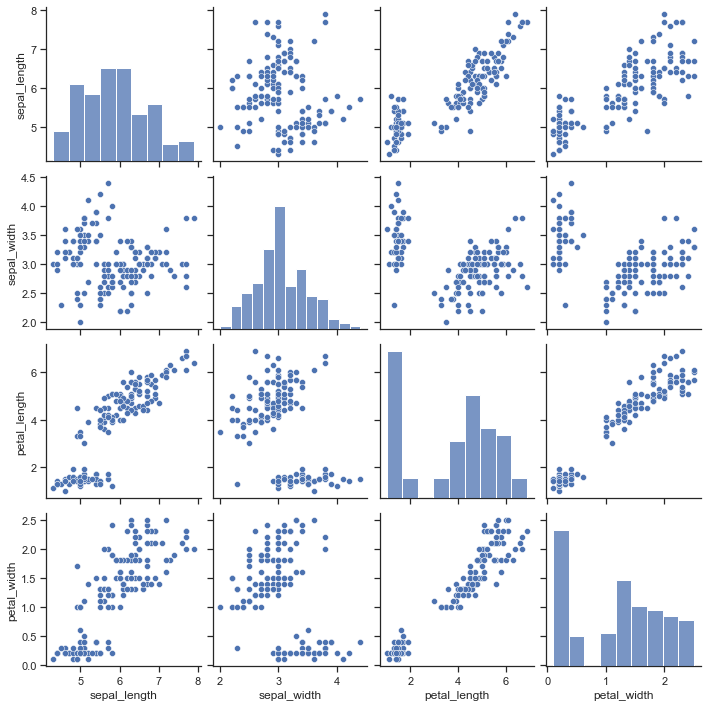

```python
sns.pairplot(iris) # 데이터가 크면 느리기에 하나씩 출력해서 분석하는 것이 좋다.
```

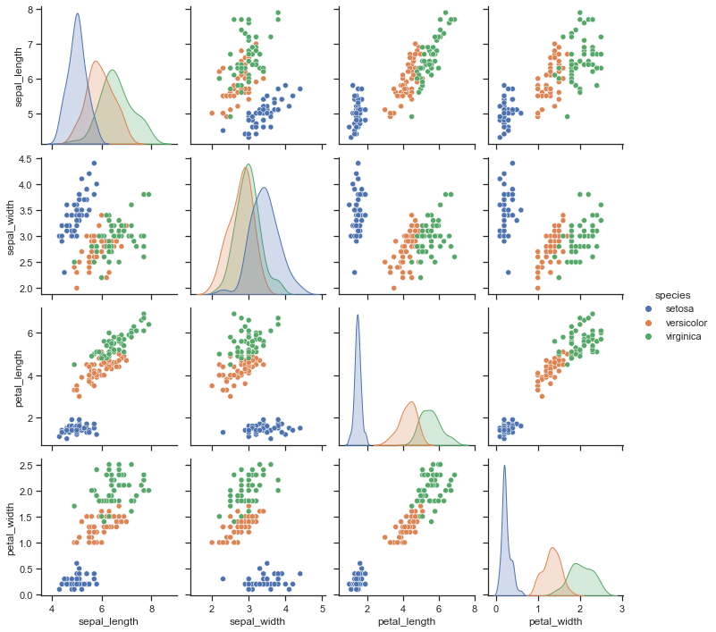

```python
sns.pairplot(iris, hue="species")
plt.show()
```